# EEN manuscript untargeted PCA

Quirin Manz

2024-03-07

## Load packages

```r
library(data.table)
library(ggfortify)
library(readxl)
library(mixOmics)
```

## Load and wrangle data

```r
metadata <- as.data.table(read_excel('Metadata_Metabolome_sample_selection_Mouse.xlsx', sheet = 1))
setnames(metadata, '...1', 'SampleID')
metadata[, SampleID := sprintf('X%03.f', SampleID)]
metadata[, Patient:=gsub(pattern = ' EEN (incomplete )?remission', replacement = '', Patient)]
metadata[, Patient:=gsub(pattern = ' PreEEN active', replacement = '', Patient, fixed = TRUE)]
metadata[, Experiment_old := Experiment]
metadata[, Experiment := gsub(pattern = '_', replacement = ' - ', MP_FMT, fixed = TRUE)]
setnames(metadata, 'inflammation', 'Inflammation')
setkey(metadata, SampleID)

data_dir <- 'HP01-Mouse jEMqEc@4c'
expression_files <- list.files(data_dir, 'ExpressenSet', full.names = TRUE)
raw_dt <- rbindlist(sapply(expression_files, function(f) read_excel(f, sheet = 'Expression'), simplify = FALSE), idcol='file')

pattern <- "(HILIC|RP)_(pos|neg)"
raw_dt[, feature:=paste0(gsub(paste0("^.*(", pattern, ").*$"), "\\1", file), '_', ID)]

melted_dt <- melt(raw_dt, id.vars = c('feature', 'file', 'ID'), variable.name = 'SampleID')
feature_dt <- dcast(melted_dt, SampleID ~ feature, value.var = 'value')
feature_columns <- names(feature_dt[, -'SampleID'])

dt <- feature_dt[metadata]
```

## PCA function

```r
na_actions <- 'half_min' #c('drop', 'mean', 'half_min', 'zero')
col_per_group <- c('inflamed' = '#eca1a2', 'not inflamed' = '#A0D29F')
shape.mapping <- c('FMT1' = 16, 'FMT3' = 17, 'FMT4' = 15)
shapes_per_group <- shape.mapping[metadata[, sapply(strsplit(unique(Experiment), " - ", fixed = TRUE), tail, 1)]]
names(shapes_per_group) <- metadata[, unique(Experiment)]

my_pca <-
  function(dt,
           filter_value,
           filter_column,
           shape_by = 'Experiment',
           color_by = 'Inflammation',
           na.threshold = 0.5,
           na.action = 'half_min',
           my_dist = 'centroids.dist',
           conduct_splsda = TRUE,
           conduct_plsda = FALSE,
           max_compn = 4,
           verbose = TRUE,
           col.per.group = col_per_group,
           shapes.per.group = shapes_per_group) {
    this_name <- paste0(
      gsub(' ', '', filter_value, fixed = TRUE), collapse = '::'
    )
    if(verbose) print(paste0('running PCA for ', this_name))
    pca_dt <- copy(dt[get(filter_column) %in% filter_value])
    if (verbose)
    print(paste0('starting with ', length(feature_columns), ' features'))
    # Remove all NA columns:
    all_na <- pca_dt[, colSums(is.na(pca_dt)) == .N]
    if (verbose) print(paste('dropping ', sum(all_na), ' features because they are all NA'))
    pca_dt <- pca_dt[,!all_na, with = FALSE]

    melted_pca_dt <- melt(pca_dt, measure.vars = feature_columns[feature_columns %in% names(pca_dt)])
    nas_per_feature <- melted_pca_dt[, .(NAs = sum(is.na(value)), N=.N), by=.(Inflammation, variable)]
    if (verbose) print(ggplot(nas_per_feature, aes(x = NAs/N, color= Inflammation)) + stat_ecdf() + scale_color_manual(values = col.per.group) + theme_bw() + labs(title='NA distribution'))

    more_than_50_na <- nas_per_feature[NAs/N > na.threshold, unique(variable)]
    if (verbose) print(paste('dropping ', length(more_than_50_na), ' features because they have > 50% NAs in one of the groups'))
    pca_mat <-
      as.matrix(pca_dt[, names(pca_dt) %in% feature_columns & !names(pca_dt) %in% more_than_50_na, with = FALSE])

    if (na.action == 'drop') {
      # Identify columns without any missing values
      non_na_columns <- !colSums(is.na(pca_mat))
      if (verbose) print(paste(
        'dropping ',
        sum(!non_na_columns),
        ' features because they contain NA values'
      ))
      # Subset the matrix to keep only columns without missing values
      pca_mat <- pca_mat[, non_na_columns]
    } else if (na.action == 'mean') {
      # Replace NA with column mean
      for (i in 1:ncol(pca_mat)) {
        pca_mat[is.na(pca_mat[, i]), i] <- mean(pca_mat[, i], na.rm = TRUE)
      }
    } else if (na.action == 'half_min') {
      # Replace NA with column mean
      for (i in 1:ncol(pca_mat)) {
        pca_mat[is.na(pca_mat[, i]), i] <-
          min(pca_mat[, i], na.rm = TRUE) / 2
      }
    } else if (na.action == 'zero') {
      # Replace NA with zero
      pca_mat[is.na(pca_mat)] <- 0
    } else {
      stop('illegal value for na.action')
    }
    # Remove columns with zero variance
    constant_cols <- apply(pca_mat, 2, var) == 0
    if (verbose) print(paste(
      'dropping ',
      sum(constant_cols),
      ' features because they are constant'
    ))
    pca_mat <- pca_mat[, !constant_cols]
    pca <- prcomp(pca_mat, scale = TRUE)
    dimred_plot <- autoplot(
      pca,
      data = pca_dt,
      colour = color_by,
      shape = shape_by,
      size = 5,
      frame = TRUE,
      frame.type = 'norm'
    ) +
      theme_bw() +
      scale_color_manual(values = col.per.group) +
      scale_shape_manual(values = shapes.per.group) +
      labs(title = paste0(filter_column, ': ', paste(filter_value, collapse = ', ')))#, '; NAs: ', na.action))
    print(dimred_plot)
    ggsave(paste0('pca_', this_name, '.pdf'))

    # Calculate variance explained
    var_explained <- pca$sdev ^ 2
    total_variance <- sum(var_explained)
    prop_var_explained <- var_explained / total_variance
    cum_var_explained <- cumsum(prop_var_explained)

    # Create a data frame for ggplot
    pca_data <- data.table(
      PC = seq_along(prop_var_explained),
      Variance = prop_var_explained,
      Cumulative = cum_var_explained
    )

    scree_plot <- ggplot(pca_data, aes(x = PC)) +
      geom_col(aes(y = Variance), fill = "blue") +
      geom_line(aes(y = Cumulative),
                color = "darkgrey",
                linetype = "dashed") +
      geom_point(aes(y = Cumulative), color = "darkgrey") +
      scale_y_continuous(breaks = seq(0, 1, by = .1)) +
      scale_x_continuous(breaks = 1:length(prop_var_explained)) +
      labs(title = "Scree Plot",
           x = "Principal Component",
           y = "Proportion of Variance Explained") + theme_bw() +
      geom_text(
        aes(y = Variance, label = sprintf("%.2f%%", Variance * 100)),
        position = position_nudge(y = 0.07),
        size = 3,
        color = "blue",
        angle = 90
      ) +
      geom_text(
        aes(y = Cumulative, label = sprintf("%.2f%%", Cumulative * 100)),
        position = position_nudge(y = -0.05),
        size = 3,
        color = "darkgrey",
        angle = 45
      )

    max_PC <- which(cum_var_explained > 0.9)[1]
    if (verbose) print(paste('90% of variance explained by', max_PC, 'PCs'))

    my_manova <-
      manova(pca[['x']][, paste0('PC', seq(max_PC))] ~ pca_dt[, Inflammation])

    if (conduct_splsda == TRUE) {
      # Tune the number of components and the number of features to keep
      if (verbose) print("Conduct splsda...")
      list.keepX <- c(1:10,  seq(20, 100, 10))
      if (verbose) print("tune...")
      nfolds <- pca_dt[, min(table(Inflammation))]
      tune_splsda <- tune.splsda(pca_mat, pca_dt[, Inflammation], ncomp = max_compn, validation = 'Mfold',
                                 folds = nfolds, dist = my_dist, progressBar = verbose,
                                 test.keepX = list.keepX, nrepeat = 50, auc = TRUE, cpus = 1)

      ncomp <- tune_splsda$choice.ncomp$ncomp
      select.keepX <- tune_splsda$choice.keepX[1:ncomp]
```

```r
      if (verbose) print(paste0('Optimal number of components: ', ncomp))
      if (verbose) print(paste0('Optimal number of features to keep: ', select.keepX))

      spls_da <- splsda(pca_mat, pca_dt[, Inflammation], ncomp = ncomp, keepX = select.keepX)
      perf_spls_da <- perf(spls_da, folds = nfolds, validation = "Mfold",
                  dist = my_dist, progressBar = verbose, nrepeat = 50)

      stability_plot <- ggplot(rbindlist(lapply(perf_spls_da$features$stable, function(x) list(feature = names(x), stability = x)), idcol = 'comp'),
                               aes(x = reorder(feature, -stability), y = as.numeric(stability), fill = comp)) +
        geom_col(position = 'dodge') +
        labs(title = 'Stability of features', x = 'Feature', y = 'Stability') +
        theme_bw() +
        theme(axis.text.x = element_text(angle = 90, vjust = .5))
      print(stability_plot)
      ggsave(paste0('stability_', this_name, '.pdf'))

      vip_dt <- as.data.table(vip(spls_da), keep.rownames = 'feature')
      melt_vip <- melt(vip_dt, id.vars = 'feature')[value > 0][order(-value)]
      if (verbose) print(melt_vip[1:10])
      fwrite(melt_vip, paste0('vip_', this_name, '.csv'))
      vip_boxplot <- ggplot(melted_pca_dt[variable %in% melt_vip[1:10, feature]],
                            aes(y = value, x = factor(variable, levels=melt_vip[1:10, unique(feature)]), color=Inflammation)) +
          geom_boxplot(width = 0.8, fill = NA, outlier.color = NA) +
          geom_point(position = position_jitterdodge(jitter.width = 0.2, jitter.height = 0),
                     aes(color = Inflammation, shape = Experiment)) +
          theme_bw() +
          scale_color_manual(values = col.per.group) +
          scale_shape_manual(values = shapes.per.group) +
          labs(title = 'Top 10 VIP features', x = 'Feature', y = 'Raw Value') +
          theme(axis.text.x = element_text(angle = 90, vjust = .5))
      print(vip_boxplot)
      ggsave(paste0('vip_', this_name, '.pdf'))

      print_comp <- c(1, 1)
      if (ncomp > 1) print_comp <- c(1, 2)
      indiv_plot <- plotIndiv(spls_da,
                              comp = print_comp,
                              ind.names = FALSE,
                              ellipse = ncomp > 1,
                              legend = TRUE,
                              col.per.group = col.per.group)

      my_ggp <- ggplot(
        cbind(indiv_plot$graph$data, pca_dt[, c('Inflammation', 'Experiment')]),
        aes(
          x = x,
          y = y,
          color = Inflammation,
          shape = Experiment
        )
      ) + geom_point(size = 3) +
        labs(
          title = paste0(
            'PLS-DA comp 1-2: ',
            filter_column,
            ': ',
            paste(filter_value, collapse = ', ')
          ),
          x = 'PLS-DA comp 1',
          y = 'PLS-DA comp 1'
        ) +
        theme_bw()

      if (ncomp > 1) {
        background <- background.predict(spls_da, comp.predicted = 2, dist = my_dist,
                                         ylim = indiv_plot$graph[["coordinates"]][["limits"]][["y"]],
                                         xlim = indiv_plot$graph[["coordinates"]][["limits"]][["x"]])
        background <-
          rbindlist(lapply(background, as.data.frame), idcol = 'Inflammation')

        my_ggp <- my_ggp + labs(y = 'PLS-DA comp 2') +
        geom_polygon(
          data = background,
          aes(x = Var1, y = Var2, fill = Inflammation),
          inherit.aes = FALSE,
          show.legend = FALSE
        ) + scale_fill_manual(values = alpha(col.per.group, .1)) + geom_point(size = 3) + scale_shape_manual(values = shapes.per.group) +
        geom_path(
          data = rbind(
            setDT(indiv_plot$df.ellipse)[, .(x = Col1, y = Col2, Inflammation = 'inflamed')],
            setDT(indiv_plot$df.ellipse)[, .(x = Col3, y = Col4, Inflammation = 'not inflamed')]
          ),
          aes(x = x, y = y, color = Inflammation),
          linewidth = 1,
          inherit.aes = FALSE
        )
      }

      my_ggp <- my_ggp + scale_color_manual(values = col.per.group)

      print(my_ggp)

      ggsave(paste0('pls_da_', this_name, '.pdf'))


      for (i in 1:ncomp){
        pdf(paste0('loadings_', this_name, '_comp', i, '.pdf'))
        plotLoadings(spls_da, comp = i, method = 'median', contrib = 'max', legend.color = col.per.group)
        dev.off()
      }

      } else if (conduct_plsda == TRUE) {
        pls_da <-
          plsda(pca_mat, pca_dt[, Inflammation], ncomp = max_compn)
        perf_pls_da <- perf(
          pls_da,
          validation = 'loo',
          progressBar = FALSE,
          auc = TRUE
        )
        # plot(perf_pls_da, sd = TRUE, legend.position = 'horizontal')

        ber_matrix <- perf_pls_da$error.rate$BER
        min_index <-
          which(ber_matrix == min(ber_matrix), arr.ind = TRUE)[1, , drop = FALSE]
        min_row <- rownames(ber_matrix)[min_index[, "row"]]
        min_distance <- colnames(ber_matrix)[min_index[, "col"]]
        min_ncomp <-
          max(as.integer(sub('comp', '', min_row, fixed = TRUE)), 2L)
        if (verbose) print(paste('min ncomp:', min_ncomp, '; min distance:', min_distance))

        # pls_da_final <- plsda(pca_mat, pca_dt[, Inflammation], ncomp = min_ncomp)
        background_pls_da_final <- background.predict(pls_da, #_final,
                                                      comp.predicted = min_ncomp,
                                                      dist = min_distance)

      indiv_plot <- plotIndiv(
        pls_da,
        #_final,
        ind.names = FALSE,
        legend = TRUE,
        col.per.group = col.per.group,
        comp = c(1, 2),
        ellipse = TRUE,
        title = ,
        # '; NAs: ', na.action),
        size.title = rel(1),
        X.label = 'PLS-DA comp 1',
        Y.label = ,
        background = background_pls_da_final
      )

      background <-
        rbindlist(lapply(background_pls_da_final, as.data.frame), idcol = 'group')
```

```r
      my_ggp <- ggplot(
        cbind(indiv_plot$graph$data, pca_dt[, 'Experiment']),
        aes(
          x = x,
          y = y,
          color = group,
          shape = Experiment
        )
      ) + geom_point() +
        labs(
          title = paste0(
            'PLS-DA comp 1-2: ',
            filter_column,
            ': ',
            paste(filter_value, collapse = ', ')
          ),
          x = 'PLS-DA comp 1',
          y = 'PLS-DA comp 2'
        ) +
        theme_bw() +
        geom_polygon(
          data = background,
          aes(x = Var1, y = Var2, fill = group),
          inherit.aes = FALSE,
          show.legend = FALSE
        ) + scale_fill_manual(values = alpha(col.per.group, .1)) + geom_point(size = 3) + scale_shape_manual(values = shapes.per.group) +
        geom_path(
          data = rbind(
            setDT(indiv_plot$df.ellipse)[, .(x = Col1, y = Col2, group = 'inflamed')],
            setDT(indiv_plot$df.ellipse)[, .(x = Col3, y = Col4, group = 'not inflamed')]
          ),
          aes(x = x, y = y, color = group),
          linewidth = 1,
          inherit.aes = FALSE
        ) + scale_color_manual(values = col.per.group)
      print(my_ggp)
      ggsave(paste0('pls_da_', this_name, '.pdf'))
    }


    list(dimred = dimred_plot,
         scree = scree_plot,
         manova = my_manova) #, pls_da_perf = pls_da_perf_plot, pls_da = pls_da_plot)
  }
```

## 1. PCA

E6, E13, E12 (patient 1)

MP1_FMT1, MP1_FMT3, MP1_FMT4,

different symbol per experiment

Inflamed (red-ish) non inflamed (green-ish)

```
## [1] "half_min"
## [1] "running PCA for Patient1"
## [1] "starting with 6342 features"
## [1] "dropping  2188  features because they are all NA"
```

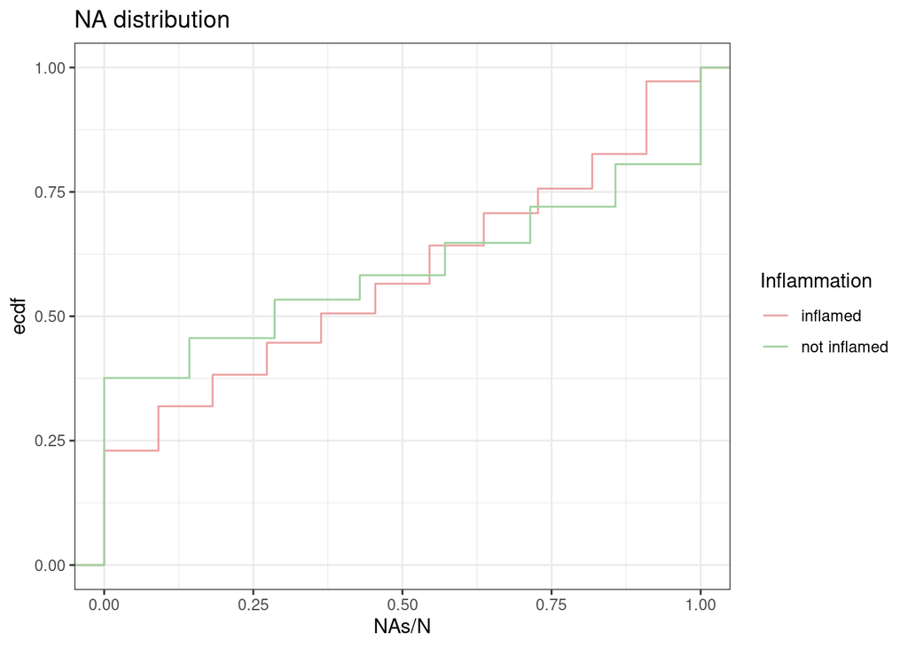

```
## [1] "dropping  2079  features because they have > 50% NAs in one of the groups"
## [1] "dropping  0  features because they are constant"
```

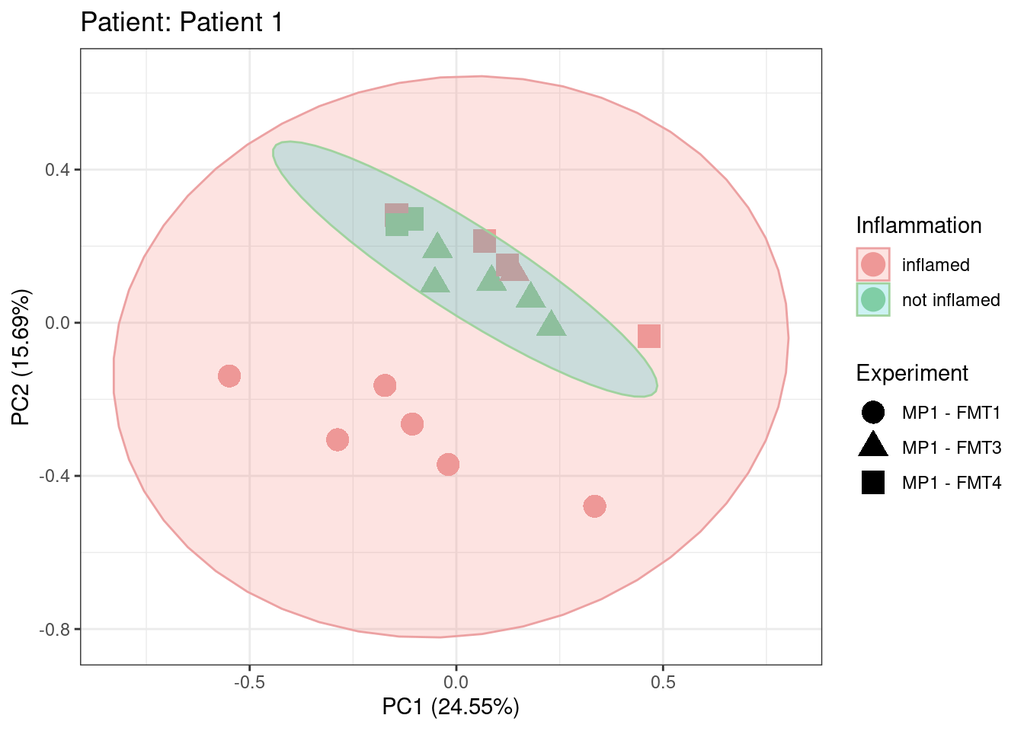

```
## [1] "90% of variance explained by 12 PCs"
## [1] "Conduct splsda..."
## [1] "tune..."
##
## comp 1
##   |                                                                              |                                                                      |   0%  |                                                                              |                                                         …
## comp 2
##   |                                                                              |                                                                      |   0%  |                                                                              |                                                         …
## comp 3
##   |                                                                              |                                                                      |   0%  |                                                                              |                                                         …
## comp 4
##   |                                                                              |                                                                      |   0%  |                                                                              |                                                         …
## [1] "Optimal number of components: 1"
## [1] "Optimal number of features to keep: 6"
##
## comp 1
##   |                                                                              |                                                                      |   0%  |                                                                              |                                                         …
```

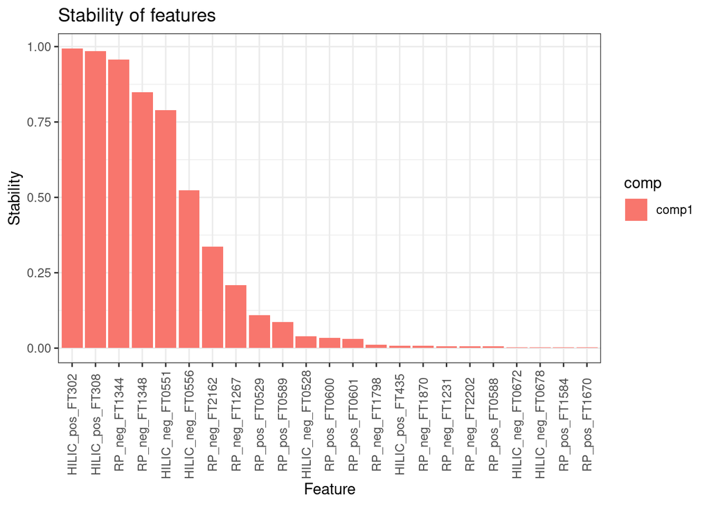

```
##              feature variable     value
##               <char>   <fctr>     <num>
##  1:  HILIC_pos_FT302    comp1 26.288141
##  2:    RP_neg_FT1344    comp1 24.369637
##  3:  HILIC_pos_FT308    comp1 20.634851
##  4:    RP_neg_FT1348    comp1 16.412685
##  5: HILIC_neg_FT0551    comp1  8.233494
##  6: HILIC_neg_FT0556    comp1  5.204874
##  7:             <NA>     <NA>        NA
##  8:             <NA>     <NA>        NA
##  9:             <NA>     <NA>        NA
## 10:             <NA>     <NA>        NA
```

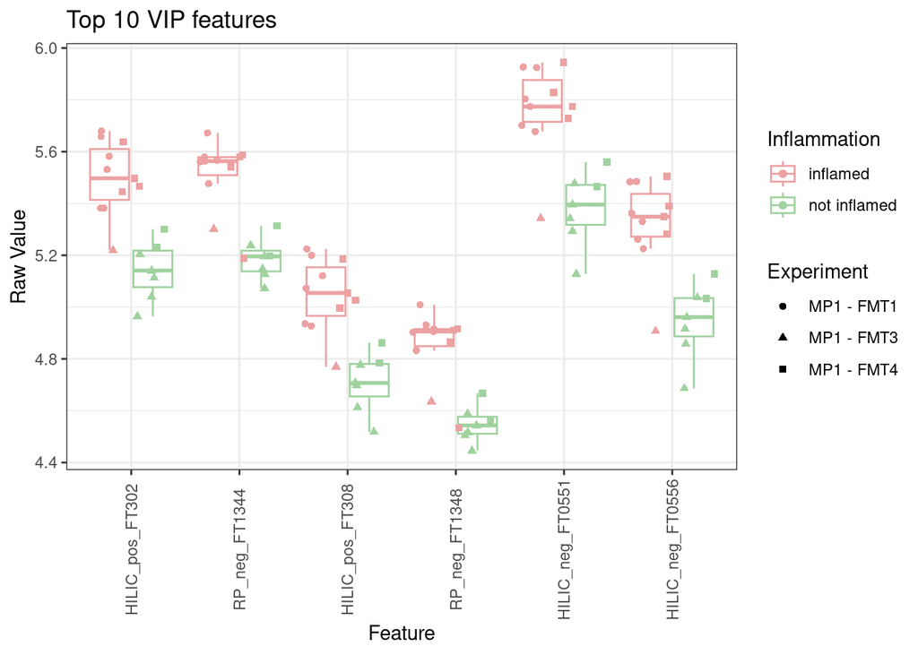

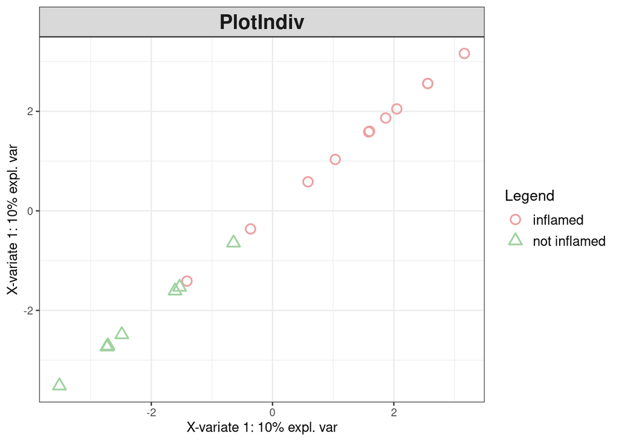

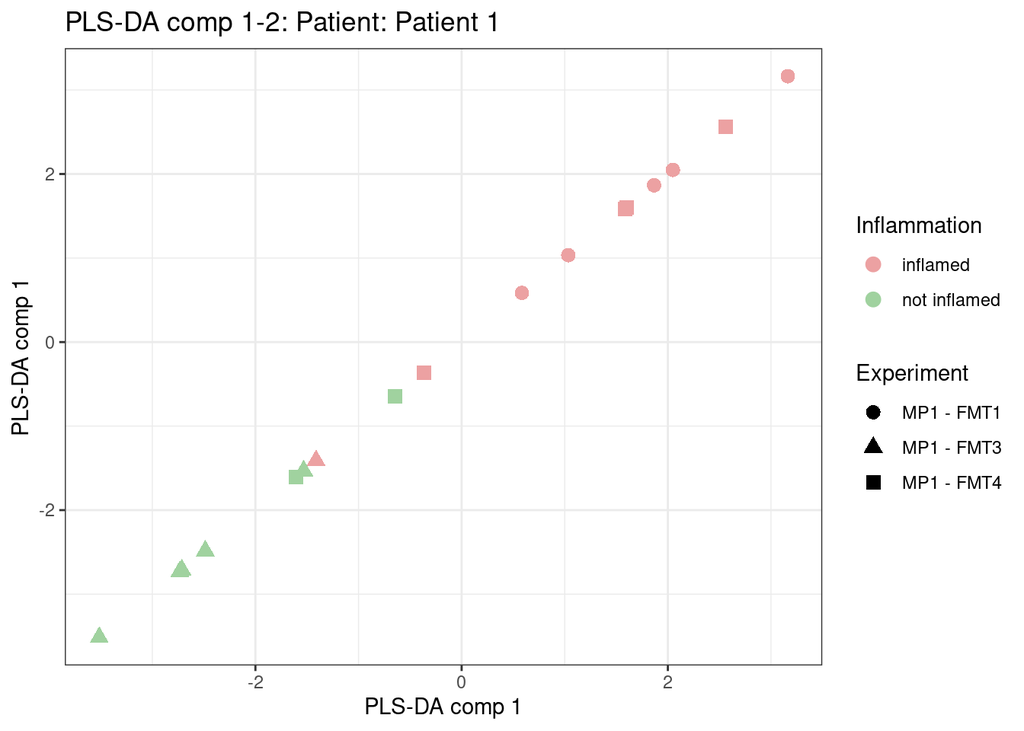

```r
for (na_action in na_actions) {
  print(na_action)
  res <- my_pca(dt, filter_value = 'Patient 1', filter_column = 'Patient', na.action = na_action)
  # print(res$dimred)
  # ggsave('pca1.pdf')
  # # print(res$scree)
  # # ggsave('scree1.pdf')
  # # print(summary(res$manova))
  # print(res$pls_da_perf)
  # print(res$pls_da_plot)
}
```

## 2. PCA

E2, E15, E20 (patient 2)

MP2_FMT1, MP2_FMT3, MP2_FMT4,

different symbol per experiment

Inflamed (red-ish) non inflamed (green-ish)

```
## [1] "half_min"
## [1] "running PCA for Patient2"
## [1] "starting with 6342 features"
## [1] "dropping  2219  features because they are all NA"
```

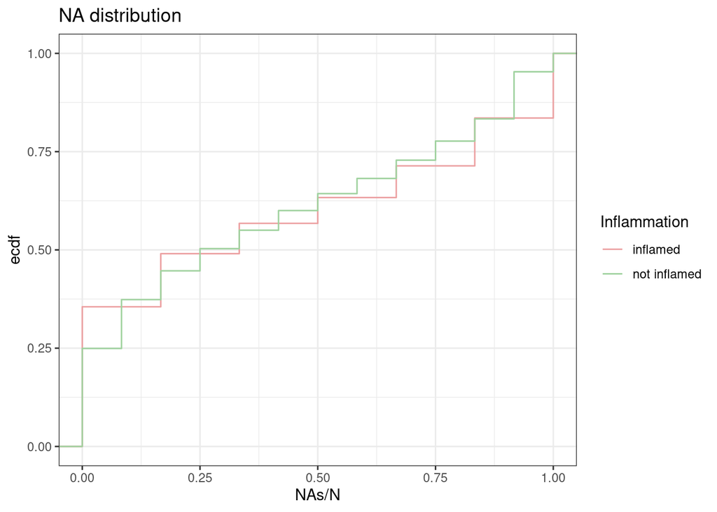

```
## [1] "dropping  1814  features because they have > 50% NAs in one of the groups"
## [1] "dropping  0  features because they are constant"
```

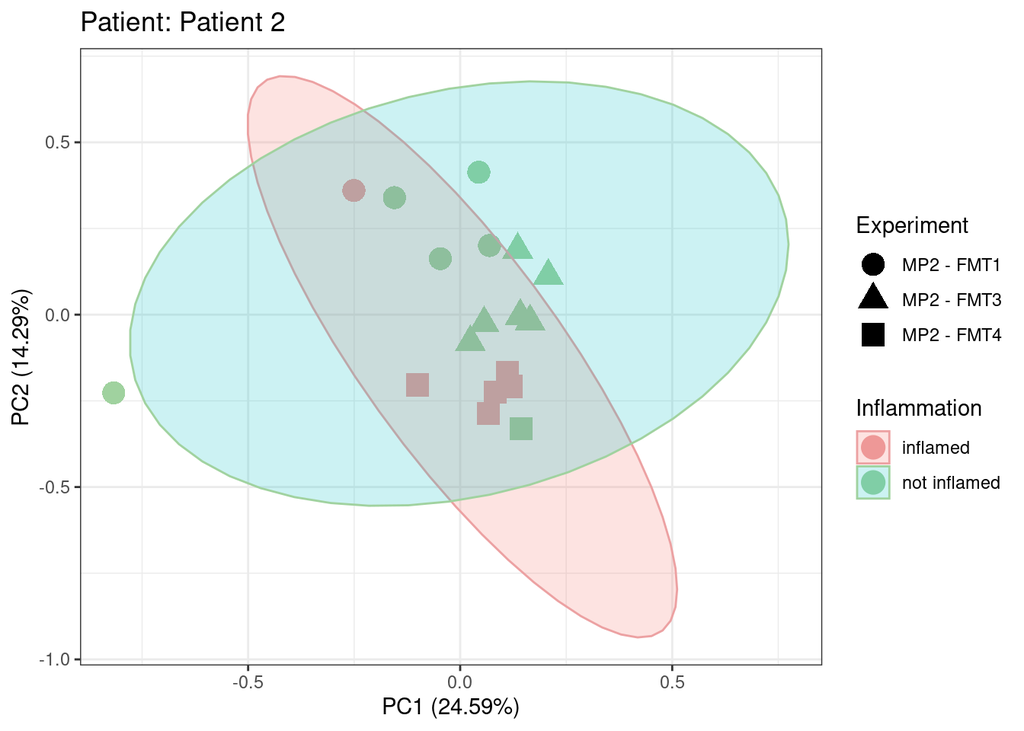

```
## [1] "90% of variance explained by 13 PCs"
## [1] "Conduct splsda..."
## [1] "tune..."
##
## comp 1
##   |                                                                              |                                                                      |   0%  |                                                                              |                                                         …
## comp 2
##   |                                                                              |                                                                      |   0%  |                                                                              |                                                         …
## comp 3
##   |                                                                              |                                                                      |   0%  |                                                                              |                                                         …
## comp 4
##   |                                                                              |                                                                      |   0%  |                                                                              |                                                         …
## [1] "Optimal number of components: 1"
## [1] "Optimal number of features to keep: 1"
##
## comp 1
##   |                                                                              |                                                                      |   0%  |                                                                              |                                                         …
```

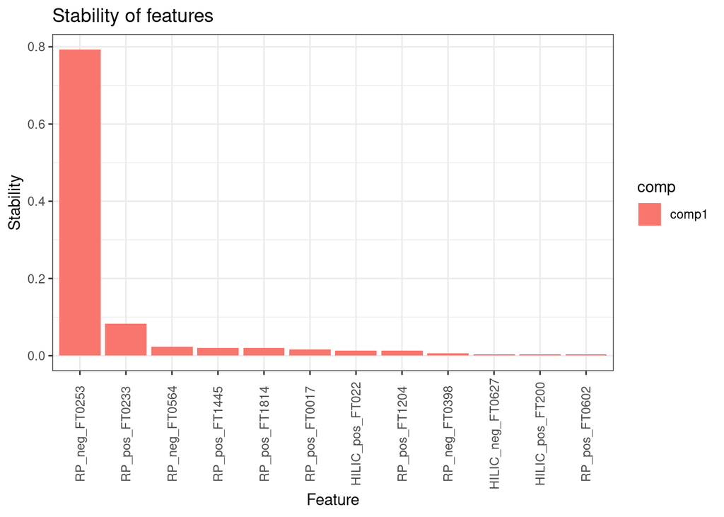

```
##           feature variable    value
##            <char>   <fctr>    <num>
##  1: RP_neg_FT0253    comp1 48.05206
##  2:          <NA>     <NA>       NA
##  3:          <NA>     <NA>       NA
##  4:          <NA>     <NA>       NA
##  5:          <NA>     <NA>       NA
##  6:          <NA>     <NA>       NA
##  7:          <NA>     <NA>       NA
##  8:          <NA>     <NA>       NA
##  9:          <NA>     <NA>       NA
## 10:          <NA>     <NA>       NA
```

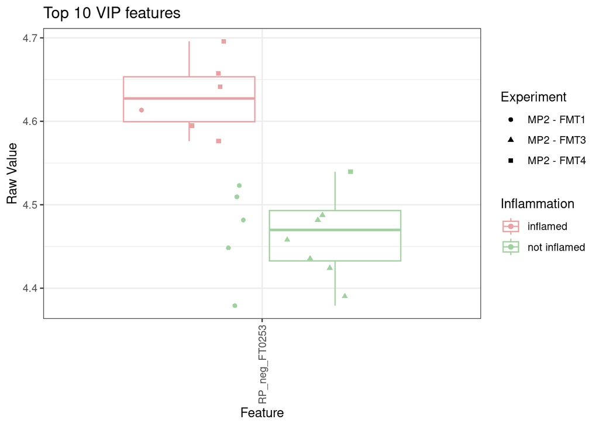

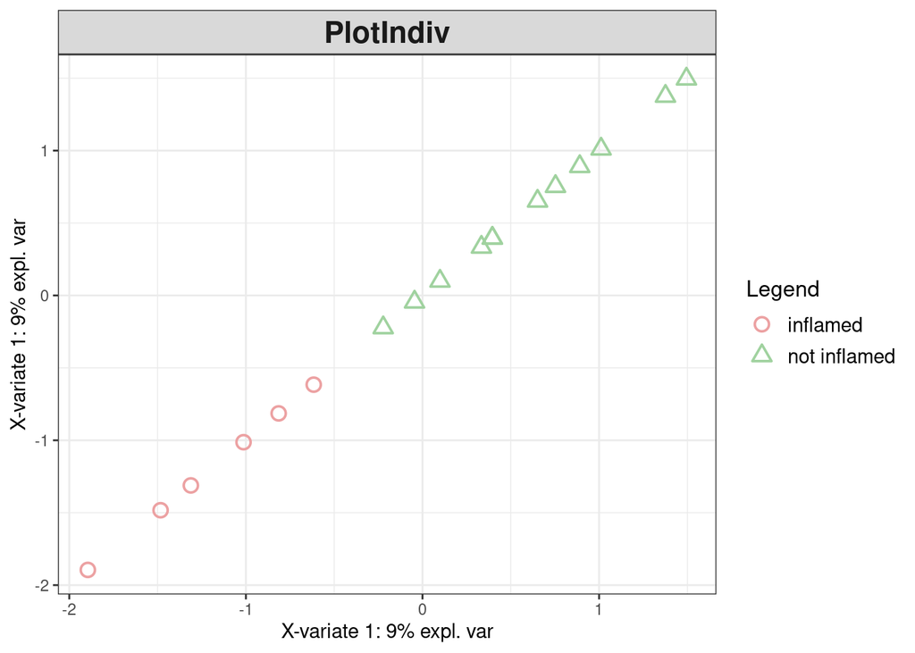

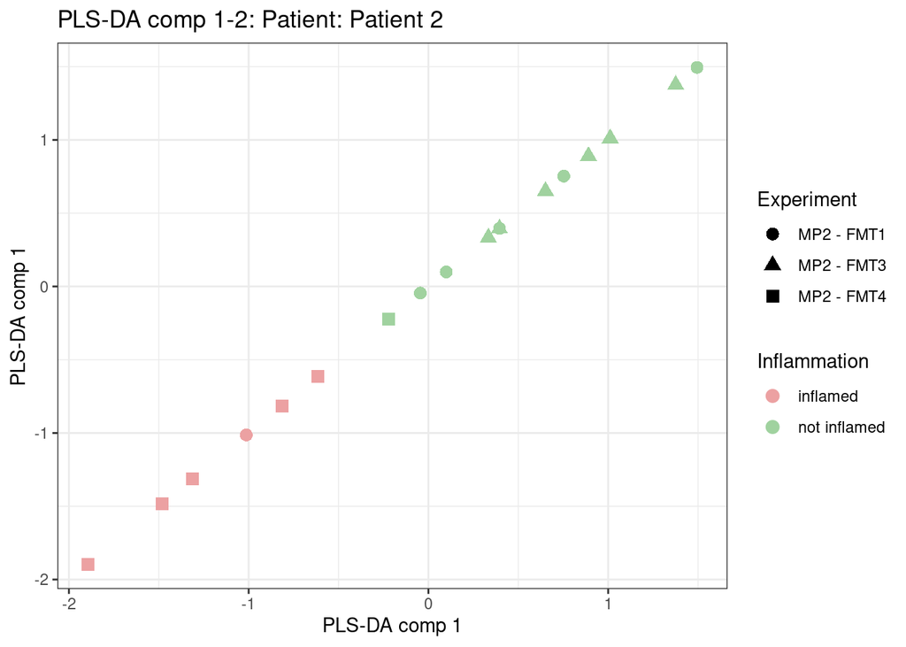

```r
for (na_action in na_actions) {
  print(na_action)
  res <- my_pca(dt, filter_value = 'Patient 2', filter_column = 'Patient', na.action = na_action)
  # print(res$dimred)
  # ggsave('pca2.pdf')
  # # print(res$scree)
  # # ggsave('scree2.pdf')
  # # print(summary(res$manova))
  # print(res$pls_da_perf)
  # print(res$pls_da_plot)
}
```

## 3. PCA

E18, E23, E27 (patient 3)

MP3_FMT1, MP3_FMT3, MP3_FMT4,

different symbol per experiment

Inflamed (red-ish) non inflamed (green-ish)

```r
for (na_action in na_actions) {
  print(na_action)
  res <- my_pca(dt, filter_value = 'Patient 3', filter_column = 'Patient', na.action = na_action)
  # print(res$dimred)
  # ggsave('pca3.pdf')
  # print(res$scree)
  # ggsave('scree3.pdf')
  # print(summary(res$manova))
}
```

```
## [1] "half_min"
## [1] "running PCA for Patient3"
## [1] "starting with 6342 features"
## [1] "dropping  2112  features because they are all NA"
```

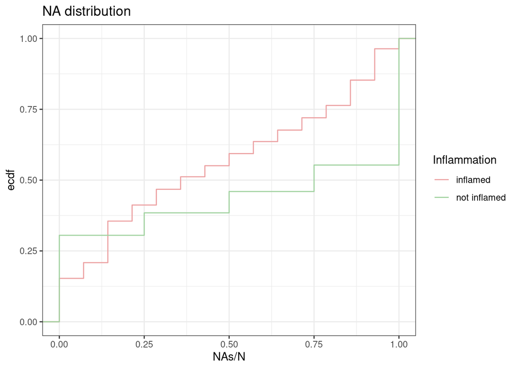

```
## [1] "dropping  2745  features because they have > 50% NAs in one of the groups"
## [1] "dropping  0  features because they are constant"
```

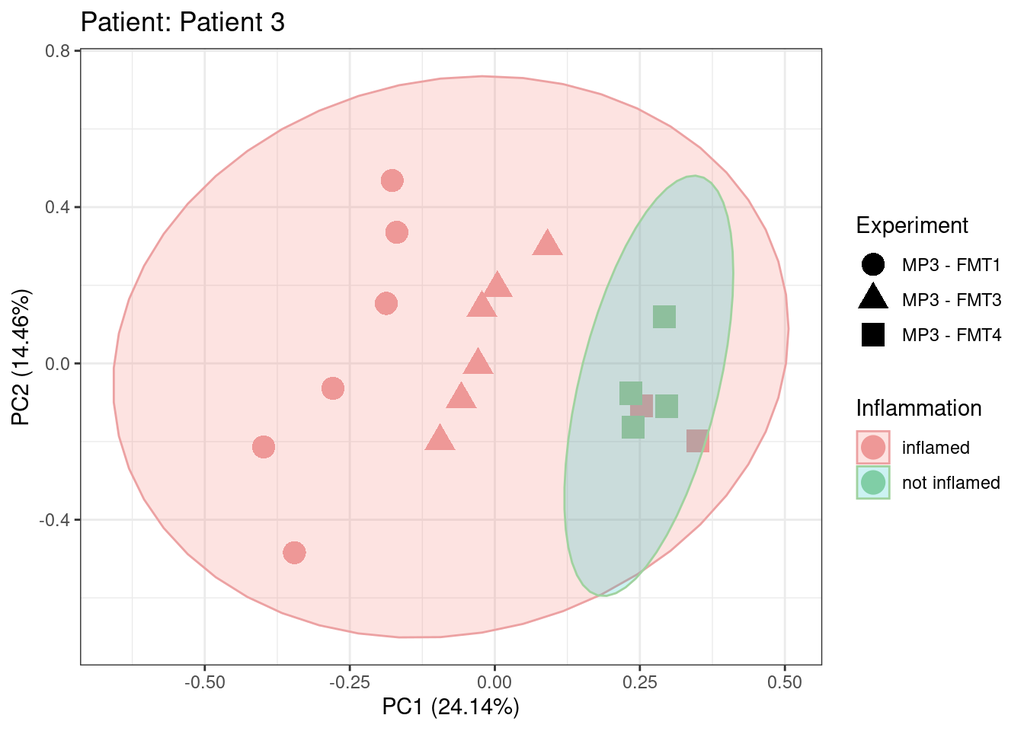

```
## [1] "90% of variance explained by 13 PCs"
## [1] "Conduct splsda..."
## [1] "tune..."
##
## comp 1
##   |                                                                              |                                                                      |   0%  |                                                                              |=                                                        …
## comp 2
##   |                                                                              |                                                                      |   0%  |                                                                              |=                                                        …
## comp 3
##   |                                                                              |                                                                      |   0%  |                                                                              |=                                                        …
## comp 4
##   |                                                                              |                                                                      |   0%  |                                                                              |=                                                        …
## [1] "Optimal number of components: 1"
## [1] "Optimal number of features to keep: 4"
##
## comp 1
##   |                                                                              |                                                                      |   0%  |                                                                              |=                                                        …
```

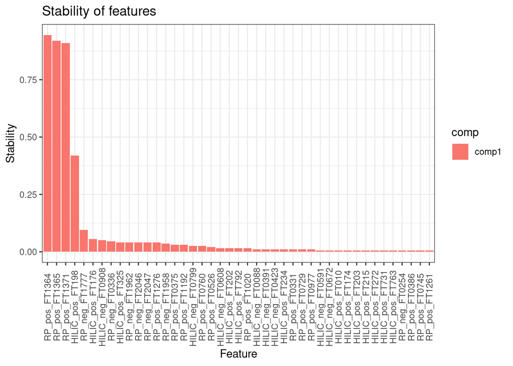

```
##             feature variable     value
##              <char>   <fctr>     <num>
##  1:   RP_pos_FT1364    comp1 21.707621
##  2:   RP_pos_FT1365    comp1 21.595532
##  3:   RP_pos_FT1371    comp1 21.543364
##  4: HILIC_pos_FT198    comp1  9.126645
##  5:            <NA>     <NA>        NA
##  6:            <NA>     <NA>        NA
##  7:            <NA>     <NA>        NA
##  8:            <NA>     <NA>        NA
##  9:            <NA>     <NA>        NA
## 10:            <NA>     <NA>        NA
```

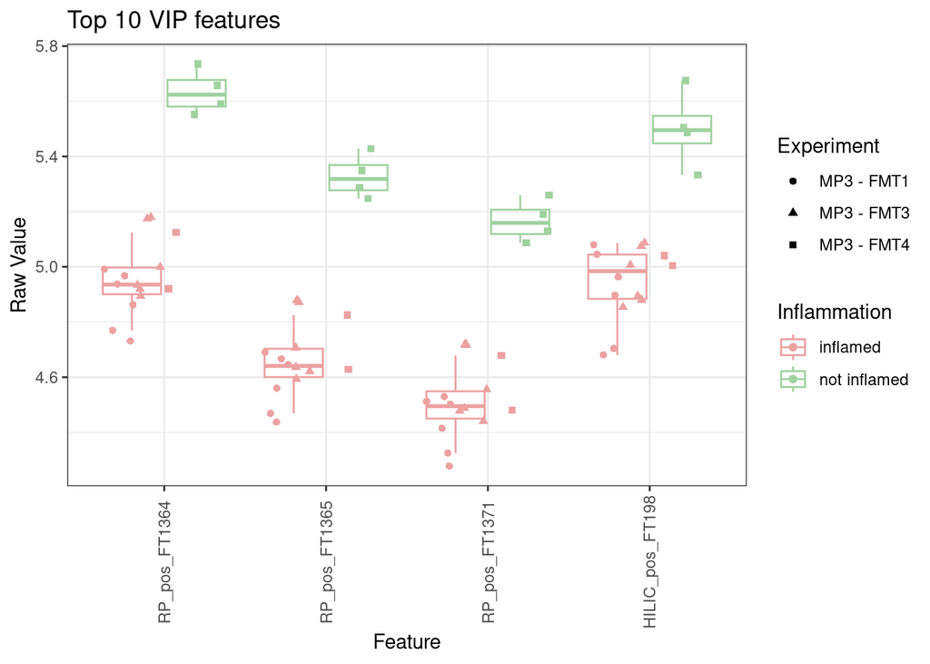

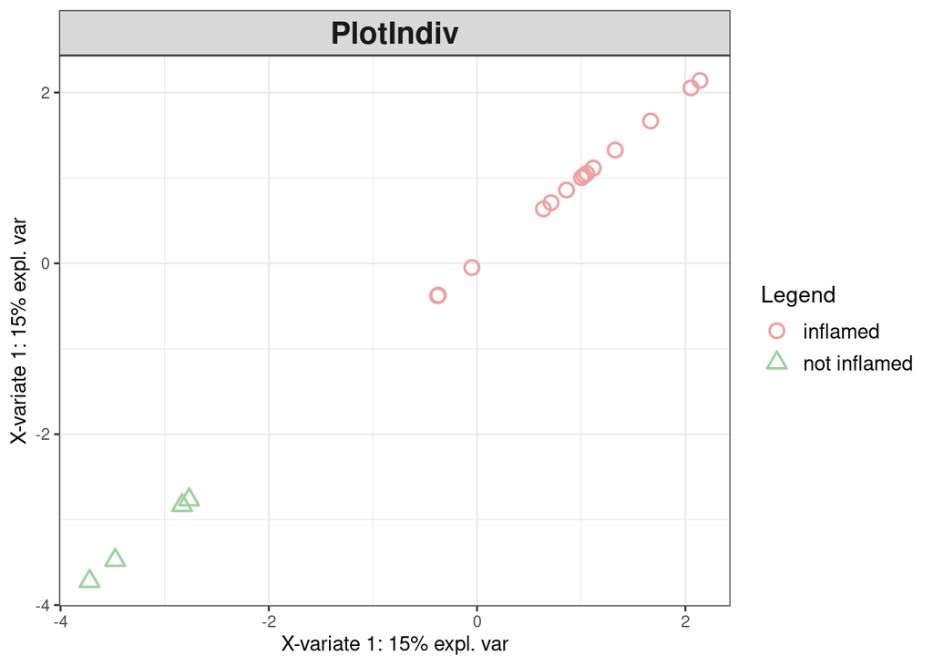

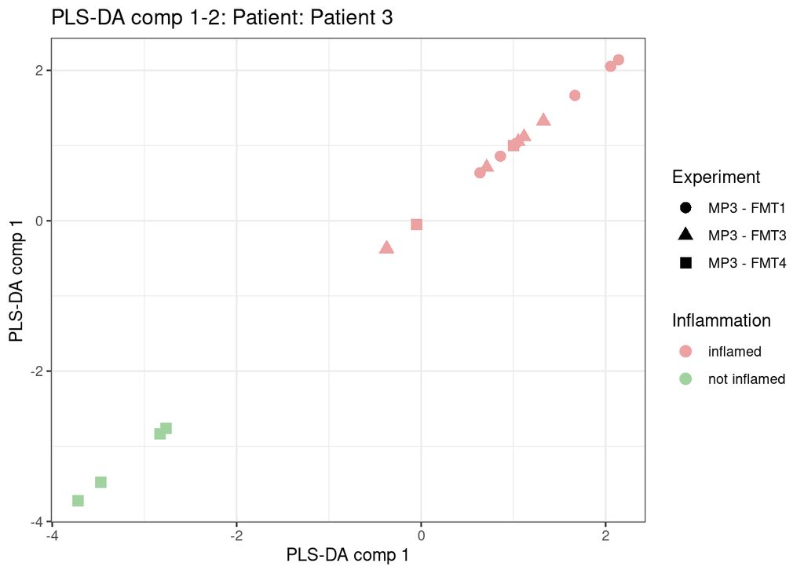

## 4. PCA

E4, E16, E25 (patient 2, relapse, supplement)

Supplement MP2_relapse_FMT1, MP2_relapse_FMT3, MP2_relapse_FMT4,

different symbol per experiment

Inflamed (red-ish) non inflamed (green-ish) (will be mostly inflamed!!)

```r
for (na_action in na_actions) {
  print(na_action)
  res <- my_pca(dt, filter_value = 'Patient 2  relapse', filter_column = 'Patient', na.action = na_action)
  # print(res$dimred)
  # ggsave('pca4.pdf')
  # print(res$scree)
  # ggsave('scree4.pdf')
  # print(summary(res$manova))
}
```

```
## [1] "half_min"
## [1] "running PCA for Patient2relapse"
## [1] "starting with 6342 features"
## [1] "dropping  1896  features because they are all NA"
```

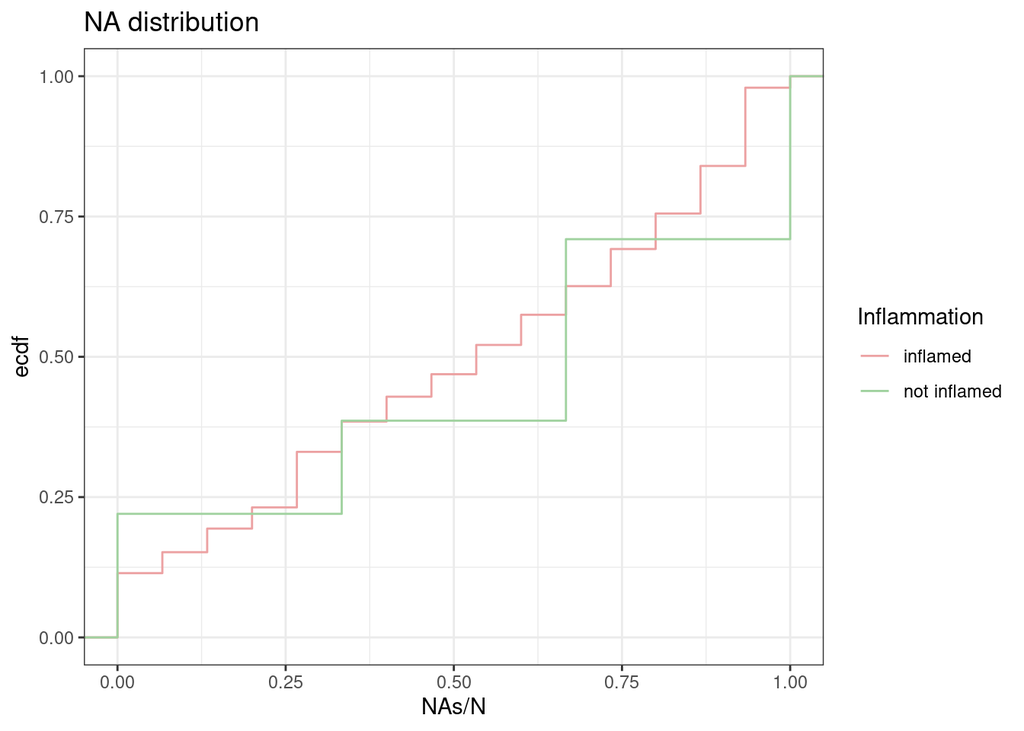

```
## [1] "dropping  3081  features because they have > 50% NAs in one of the groups"
## [1] "dropping  0  features because they are constant"
```

```
## Too few points to calculate an ellipse
## Too few points to calculate an ellipse
```

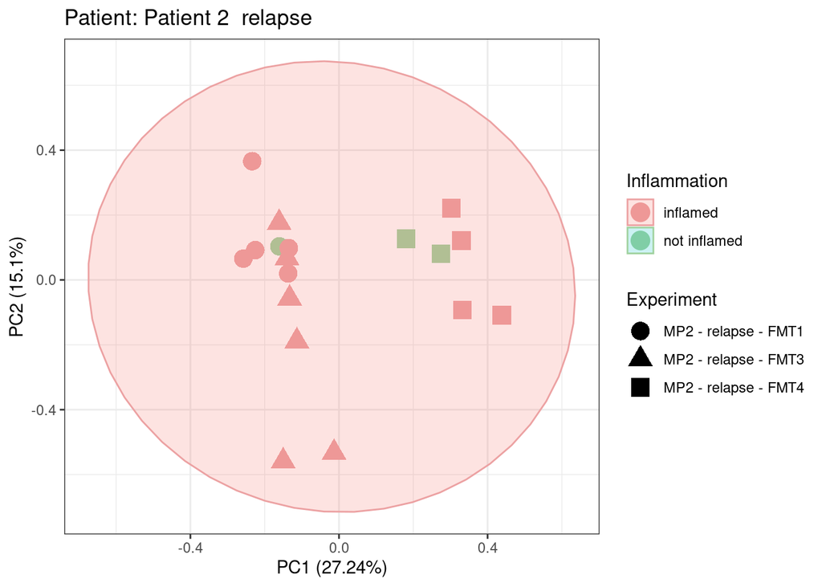

[output not shown]

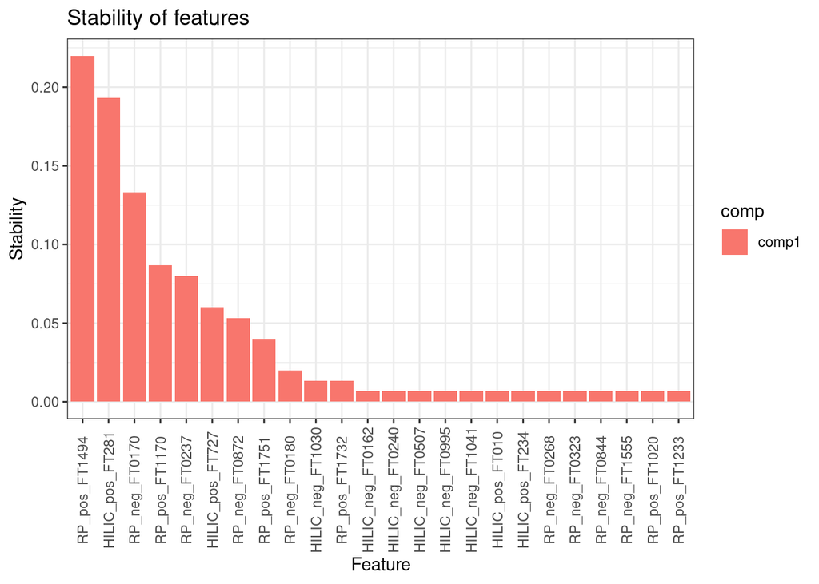

```
##           feature variable    value
##            <char>   <fctr>    <num>
##  1: RP_neg_FT0170    comp1 36.94591
##  2:          <NA>     <NA>       NA
##  3:          <NA>     <NA>       NA
##  4:          <NA>     <NA>       NA
##  5:          <NA>     <NA>       NA
##  6:          <NA>     <NA>       NA
##  7:          <NA>     <NA>       NA
##  8:          <NA>     <NA>       NA
##  9:          <NA>     <NA>       NA
## 10:          <NA>     <NA>       NA
```

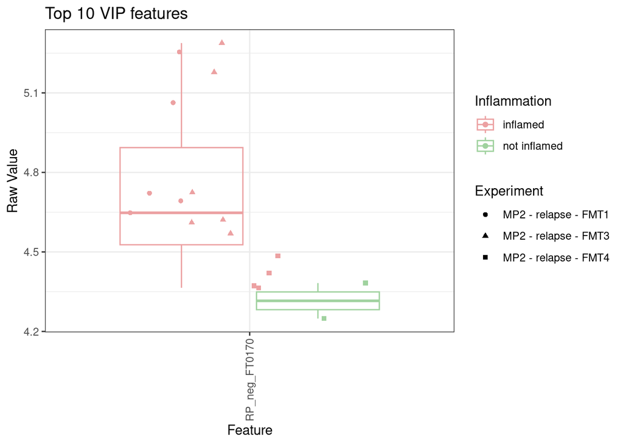

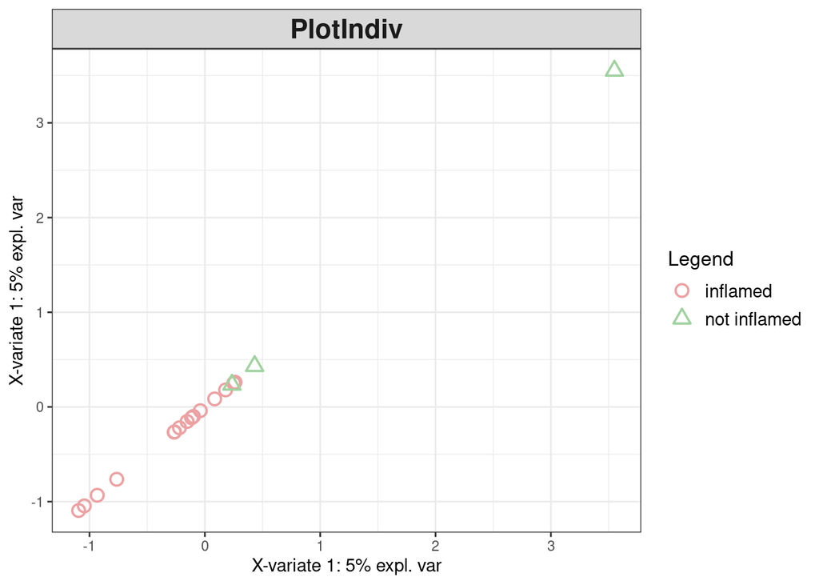

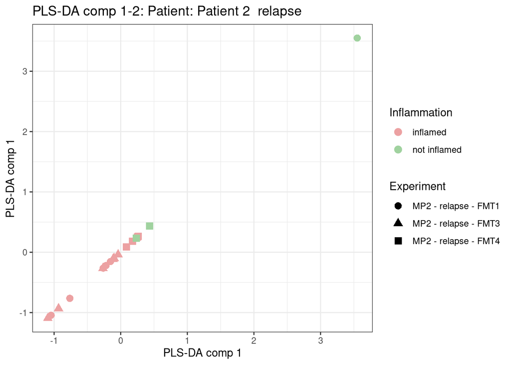

## 5. PCA

alle außer E4, E16, E25

Summary of MP1, MP2, MP3, exclusive relapse

inflamed (red-ish) non inflamed (green-ish)

```r
new_shapes <- c(
  'MP1 - FMT1' = 2,   # Triangle (empty)
  'MP1 - FMT3' = 11,   # Triangle (crossed)
  'MP1 - FMT4' = 17,  # Triangle (filled)
  'MP2 - FMT1' = 0,   # Square (empty)
  'MP2 - FMT3' = 7,   # Square (crossed)
  'MP2 - FMT4' = 15,  # Square (filled)
  'MP3 - FMT1' = 1,   # Circle (empty)
  'MP3 - FMT3' = 13,  # Circle (crossed)
  'MP3 - FMT4' = 16   # Circle (filled)
)

for (na_action in na_actions) {
  print(na_action)
  res <- my_pca(dt, filter_value = c('Patient 1', 'Patient 2', 'Patient 3'), filter_column = 'Patient', shapes.per.group = new_shapes, na.action = na_action)
  # print(res$dimred)
  # ggsave('pca5.pdf')
  # print(res$scree)
  # ggsave('scree5.pdf')
  # print(summary(res$manova))
}
```

```
## [1] "half_min"
## [1] "running PCA for Patient1::Patient2::Patient3"
## [1] "starting with 6342 features"
## [1] "dropping  1204  features because they are all NA"
```

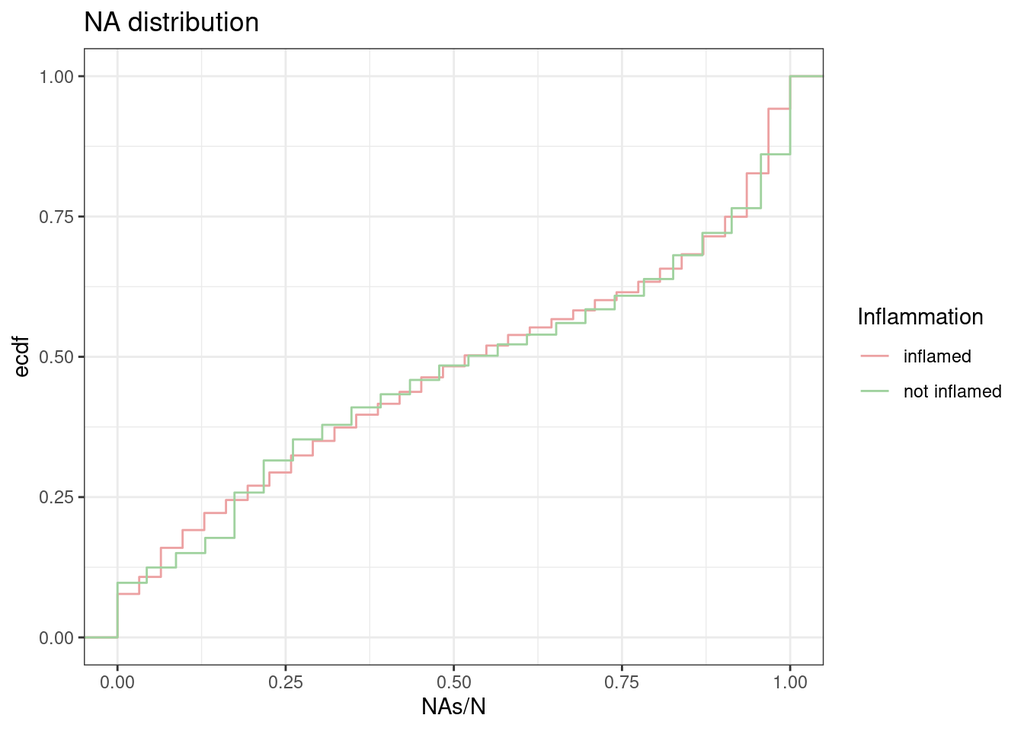

```
## [1] "dropping  2936  features because they have > 50% NAs in one of the groups"
## [1] "dropping  0  features because they are constant"
```

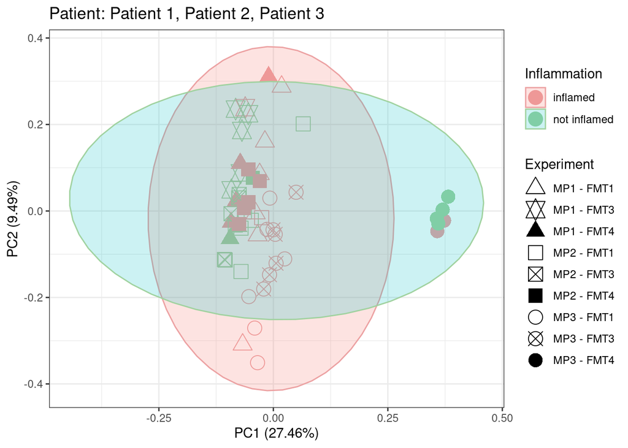

[output not shown]

[figure not shown]

```
##              feature variable     value
##               <char>   <fctr>     <num>
##  1:    RP_neg_FT0658    comp1 15.215964
##  2:    RP_neg_FT0658    comp2 13.003979
##  3:    RP_neg_FT1620    comp1 12.106437
##  4:    RP_neg_FT1620    comp2 10.346492
##  5: HILIC_neg_FT0499    comp1 10.137143
##  6:    RP_neg_FT2253    comp1  9.487242
##  7: HILIC_neg_FT0499    comp2  8.663480
##  8: HILIC_neg_FT1090    comp1  8.376009
##  9:    RP_neg_FT2253    comp2  8.108057
## 10: HILIC_neg_FT1119    comp1  8.092118
```

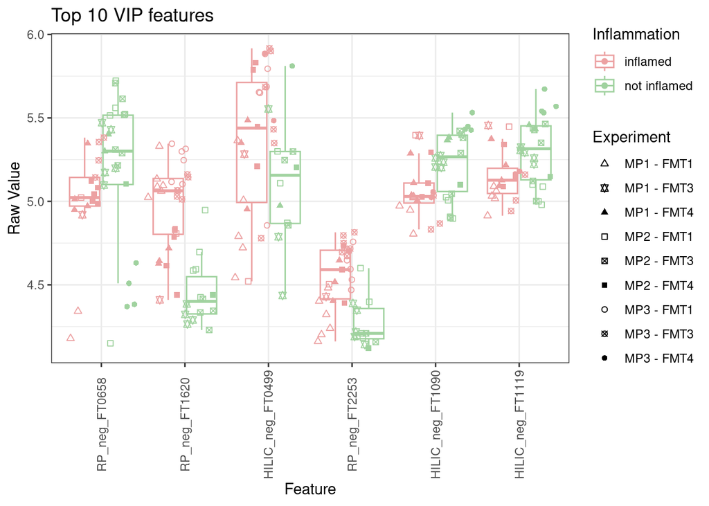

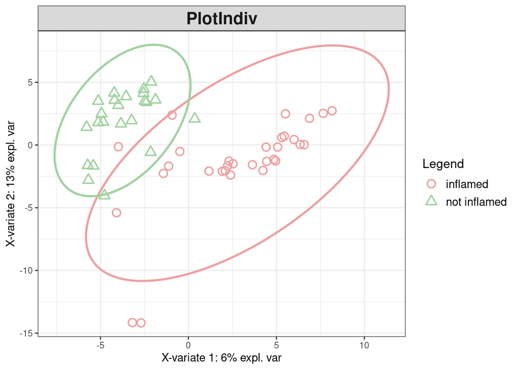

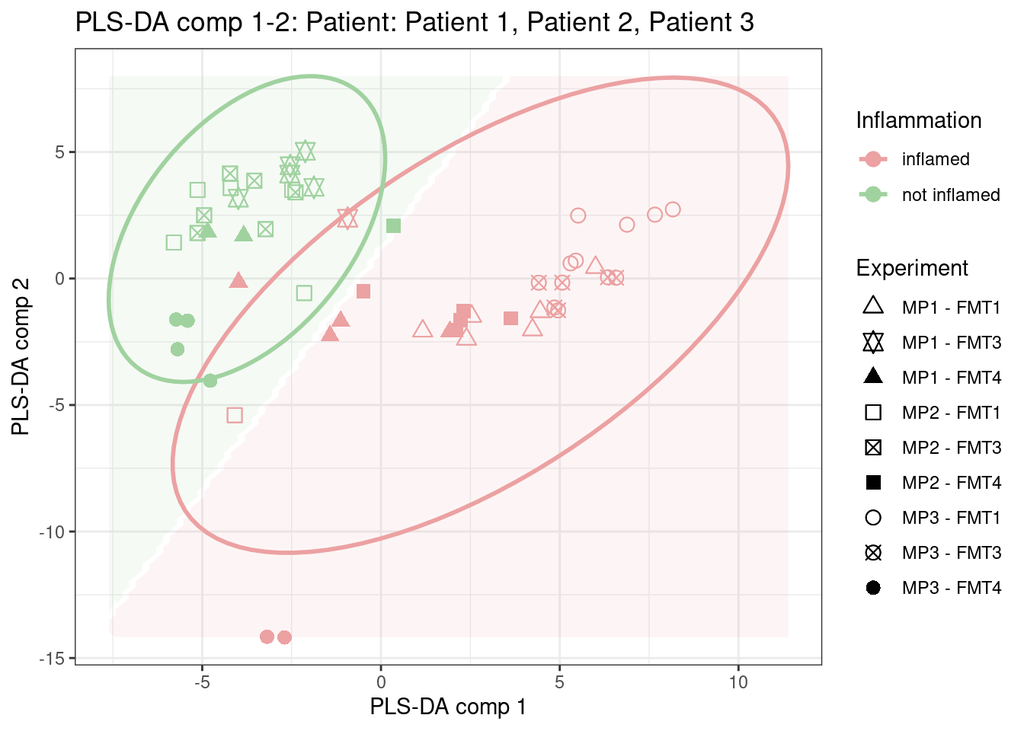